# Sampling distributions & the Central Limit Theorem

2022-03-04

# Bulletin

- [project report info](https://sta199-sp22-003.netlify.app/project/project.html)
- lab 06 can be turned in until Monday March 14 at 11:59p
- Statistics experience (homework) released
- Due today:
  - homework 04
  - quiz 05

# Today

By the end of today you will

- Use Central Limit Theorem to define distribution of sample means
- Calculate probabilities from the normal distribution

```r
library(tidyverse)
```

# What is the Central Limit Theorem?

The central limit theorem is a statement about the distribution of the sample mean, $\bar{x}$

The central limit theorem guarantees that, when certain criteria are satisfied, the sample mean ($\bar{x}$) is normally distributed.

Specifically,

If

1. Observations in the sample are independent. Two rules of thumb to check this:
   - completely random sampling
   - if sampling without replacement, sample should be less than 10% of the population size

and

2. The sample is large enough. The required size varies in different contexts, but some good rules of thumb are:
   - if the population itself is normal, sample size does not matter.
   - if numerical require, >30 observations
   - if binary outcome, at least 10 successes and 10 failures.

then

$\bar{x} \sim N(\mu, \sigma / \sqrt{n})$

i.e. $\bar{x}$ is normally distributed (unimodal and symmetric with bell shape) with mean $\mu$ and standard deviation $\sigma / \sqrt{n}$.

Note the standard deviation depends on the number of samples, $n$.

# Practice using CLT & Normal distribution

Suppose the bone density for 65-year-old women is normally distributed with mean $809 mg/cm^3$ and standard deviation of $140 mg/cm^3$.

Let $x$ be the bone density of 65-year-old women. We can write this distribution of $x$ in mathematical notation as

$$x \sim N(809, 140)$$

## Visualize the population distribution

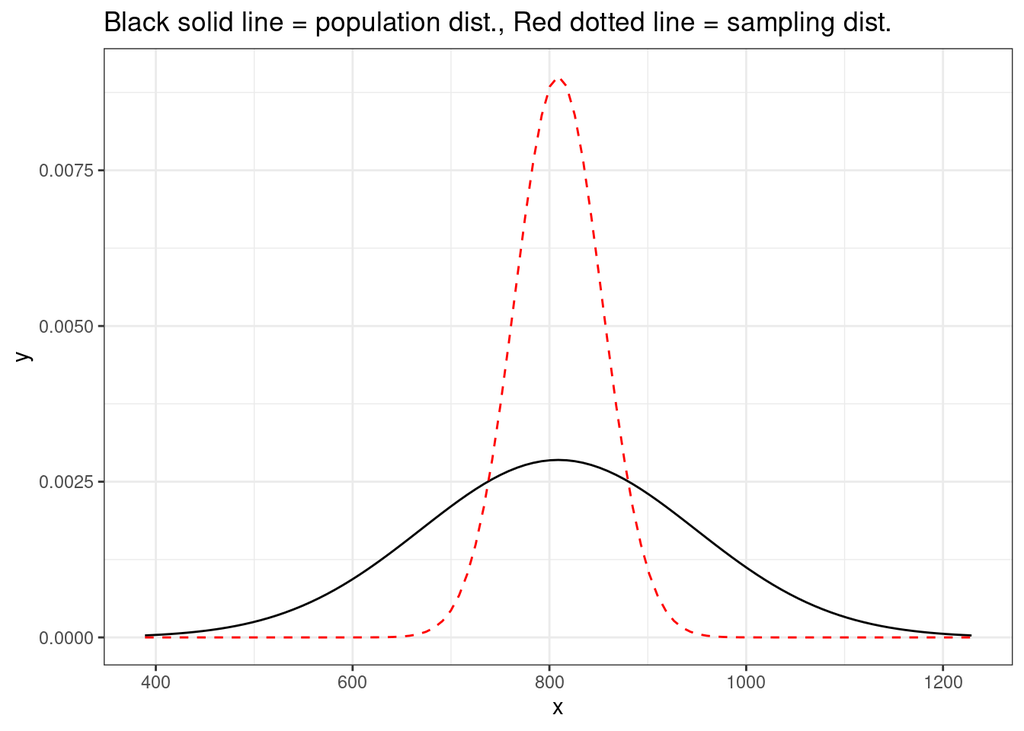

```r
ggplot(data = data.frame(x = c(809 - 140*3, 809 + 140*3)), aes(x = x)) +
  stat_function(fun = dnorm, args = list(mean = 809, sd = 140),
                color = "black") +
  stat_function(fun = dnorm, args = list(mean = 809, sd = 140/sqrt(10)),
                color = "red",lty = 2) + theme_bw() +
  labs(title = "Black solid line = population dist., Red dotted line = sampling dist.")
```

## Exercise 1

Before typing any code, based on what you know about the normal distribution, what do you expect the median bone density to be?

What bone densities correspond to $Q_1$ (25th percentile), $Q_2$ (50th percentile), and $Q_3$ (the 75th percentile) of this distribution? Use the `qnorm()` function to calculate these values.

## Exercise 2

The densities of three woods are below:

- Plywood: 540 mg/cubic centimeter
- Pine: 600 mg/cubic centimeter
- Mahogany: 710 mg/cubic centimeter
- What is the probability that a randomly selected 65-year-old woman has bones less dense than Pine?
- Would you be surprised if a randomly selected 65-year-old woman had bone density less than Mahogany? What if she had bone density less than Plywood? Use the respective probabilities to support your response.

## Exercise 3

Suppose you want to analyze the mean bone density for a group of 10 randomly selected 65-year-old women.

- Are the conditions met use the Central Limit Theorem to define the distribution of $\bar{x}$, the mean density of 10 randomly selected 65-year-old women?
  - Independence?
  - Sample size/distribution?
- What is the shape, center, and spread of the distribution of $\bar{x}$, the mean bone density for a group of 10 randomly selected 65-year-old women?
- Write the distribution of $\bar{x}$ using mathematical notation.

## Exercise 4

- What is the probability that the mean bone density for the group of 10 randomly-selected 65-year-old women is less dense than Pine?
- Would you be surprised if a group of 10 randomly-selected 65-year old women had a mean bone density less than Mahogany? What the group had a mean bone density less than Plywood? Use the respective probabilities to support your response.

## Exercise 5

Explain how your answers differ in Exercises 2 and 4.